# Goodness of Fit Example

# Problem Statement

A particular brand of candy-coated chocolate comes in five different colors: brown, yellow, orange, green, and coffee. The manufacturer of the candy says the candies are distributed in the following proportions: brown - 40%, yellow - 20%, orange = 20%, and the remaining are split evenly between green and coffee. A random sample of 580 pieces of this candy are collected. Does this random sample provide evidence against the manufacturer’s claim? [Tweaked a bit from https://onlinecourses.science.psu.edu/stat500/node/56]

# Competing Hypotheses

## In words

- Null hypothesis: The true proportions of a particular brand of candy-coated chocolate match what the manufacturer states: brown - 40%, coffee - 10%, green - 10%, orange = 20%, and yellow - 20%.
- Alternative hypothesis: The distribution of candy proportions differs from what the manufacturer states.

## In symbols (with annotations)

- $H_0: P_1 = p_{1, 0}, P_2 = p_{2, 0}, P_3 = p_{3, 0}, P_4 = p_{4, 0}, P_5 = p_{5, 0}$, where $P$ represents the true proportion of colored candies (1 is “brown”, 2 is “coffee”, 3 is “green”, 4 is “orange”, and 5 is “yellow”) and $(p_{1, 0}, p_{2, 0}, p_{3, 0}, p_{4, 0}, p_{5, 0}) = ( 0.4, 0.1, 0.1, 0.2, 0.2 )$.
- $H_a:$ At least one $P_i \ne p_{i, 0}$ for $i \in \{ 1, \ldots, 5 \}$

## Set $\alpha$

It’s important to set the significance level before starting the testing using the data. Let’s set the significance level at 5% here.

# Exploring the sample data

```r
candies <- read_csv("candies.csv") |>
  mutate(candy_colors = factor(candy_colors))
```

```r
candies |>
  tabyl(candy_colors)
```

```
##  candy_colors   n  percent
##         brown 224 0.386207
##        coffee  59 0.101724
##         green  48 0.082759
##        orange 130 0.224138
##        yellow 119 0.205172
```

The bar graph below also shows the distribution of `candy_colors`.

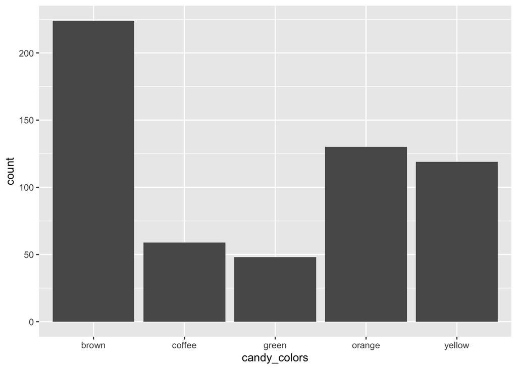

```r
ggplot(data = candies, mapping = aes(x = candy_colors)) +
  geom_bar()
```

## Guess about statistical significance

These proportions all look relatively close to the expected distributions. The sample size is relatively big, so that might lead us to reject the null hypothesis. Green and orange both have observed proportions that may lead us to reject. Let’s make the guess that we will reject $H_0$, but it might be close.

# Non-traditional methods

We’ll use the **`infer`** package to carry out the simulation-based workflow with the $\chi^2$ statistic. Because this is a single categorical variable with a hypothesized distribution, we use a `"point"` null with the claimed proportions and `generate(type = "draw")`.

```r
p_null <- c(brown = 0.4, coffee = 0.1, green = 0.1, orange = 0.2, yellow = 0.2)
```

## Observed statistic

```r
chisq_hat <- candies |>
  specify(response = candy_colors) |>
  hypothesize(null = "point", p = p_null) |>
  calculate(stat = "Chisq")
chisq_hat
```

```
## Response: candy_colors (factor)
## Null Hypothesis: point
## # A tibble: 1 × 1
##    stat
##   <dbl>
## 1  3.78
```

## Simulation for Hypothesis Test

```r
set.seed(2018)
null_distn <- candies |>
  specify(response = candy_colors) |>
  hypothesize(null = "point", p = p_null) |>
  generate(reps = 10000, type = "draw") |>
  calculate(stat = "Chisq")
```

The $\chi^2$ statistic is always non-negative, so this is a one-sided (right-tailed) test.

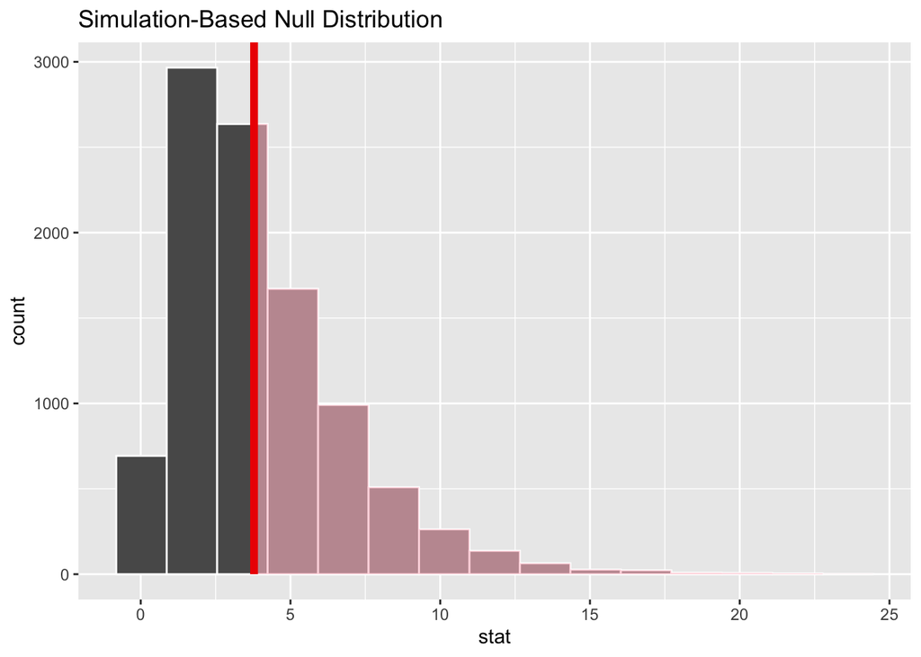

```r
null_distn |>
  visualize() +
  shade_p_value(obs_stat = chisq_hat, direction = "greater")
```

We can also overlay the theoretical $\chi^2$ distribution:

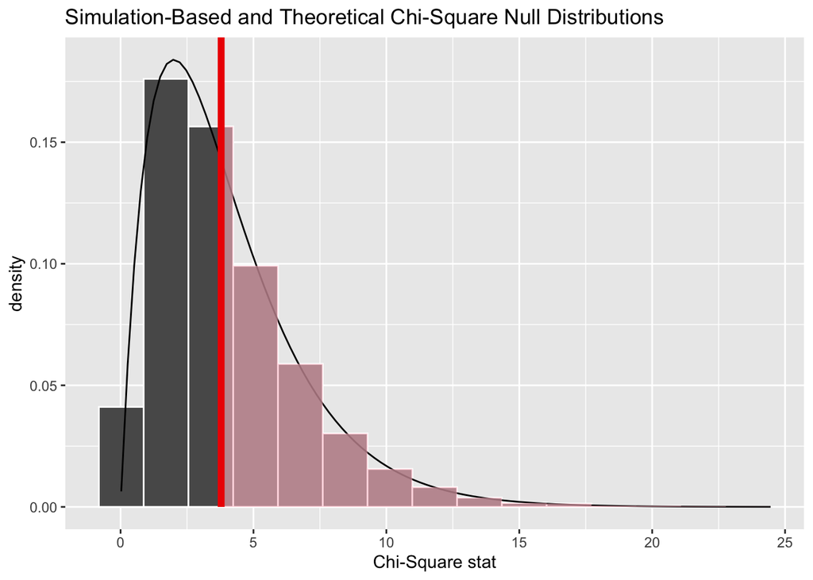

```r
null_distn |>
  visualize(method = "both") +
  shade_p_value(obs_stat = chisq_hat, direction = "greater")
```

### Calculate $p$-value

```r
pvalue <- null_distn |>
  get_p_value(obs_stat = chisq_hat, direction = "greater")
pvalue
```

```
## # A tibble: 1 × 1
##   p_value
##     <dbl>
## 1   0.431
```

So our $p$-value is 0.4308 and we fail to reject the null hypothesis at the 5% level.

# Traditional methods

## Check conditions

Remember that in order to use the shortcut (formula-based, theoretical) approach, we need to check that some conditions are met.

1. *Independent observations*: The observations are collected independently.

   The cases are selected independently through random sampling so this condition is met.
2. *Expected cell counts*: All expected cell counts are at least 5.

   $580 \cdot 0.1 = 58$ and since 0.1 is the smallest expected proportion, this condition is met.
3. *Degrees of freedom*: The degrees of freedom must be at least 2.

   There are five different groups of candy colors here so our degrees of freedom is 4.

## Test statistic

The Pearson’s $\chi^2$ test statistic measures the differences between what we actually observed for counts and what we expected for counts, summing the ratio of the squared difference in observed minus expected counts divided by expected counts over all cells. If the conditions are met and assuming the null hypothesis is true, this test statistic follows a $\chi^2$ distribution with $k - 1$ degrees of freedom with $k$ corresponding to the number of groups of the variable of interest.

$$X^2 = \sum_{\text{all cells}}
\dfrac{\text{(observed - expected)}^2}{\text{expected}} \sim \chi^2 (df
= k - 1)$$

## Observed test statistic

`infer`’s `chisq_test()` wrapper does not cover the one-variable goodness-of-fit case, so we use the `chisq.test()` function directly with the hypothesized proportions:

```r
chisq.test(x = table(candies$candy_colors), p = p_null)
```

```
##
##  Chi-squared test for given probabilities
##
## data:  table(candies$candy_colors)
## X-squared = 3.78, df = 4, p-value = 0.44
```

## Compute $p$-value

The theory-based $p$-value closely matches the simulation-based $p$-value from above, both leading to the same conclusion.

# State conclusion

We, therefore, do not have sufficient evidence to reject the null hypothesis. Our initial guess that we would find evidence that the distribution differed compared to what was expected was incorrect. Based on this sample, we do not have evidence that the true proportions of candy colors for this type of candy is different from what the manufacturer claimed.

# Comparing results

The simulation-based and theory-based approaches give very similar $p$-values here, as the overlaid distributions above suggest. Since the conditions for the theory-based test are met, both the simulation and $\chi^2$-distribution approaches lead to the same conclusion.